# Wild plants of the mangrove: swamp

Malcolm Ross

## 1. Introduction

Mangrove forests are located on the strip of waterlogged land between mean sea level and the highest tide levels. Mangrove plants thrive in this intertidal zone because they are salt-tolerant, but they also require a supply of fresh water. One salt-resisting mechanism is ultrafiltration, which costs the plant no energy but removes sodium and chloride ions from seawater as it is absorbed for normal physiological processes. Mangrove plants are popularly recognised by the stilt roots characteristic of trees toward the seaward margin of the swamp. The exposed roots have special lenticels (pore-like structures) which enable them to exchange carbon dioxide and oxygen, allowing them to survive in anaerobic soils, while flooding tides bring water-borne nutrients and disperse their buoyant seeds (Duke 2006). Not all mangroves have stilt roots, however.

Serious deforestation of the intertidal zone occurred on many Pacific islands after the arrival of European colonisers, thanks to a perception that mangrove areas were unproductive marginal lands (Thaman 1994: 157), but Hviding’s (2005) study of plant use on Marovo Lagoon shows vividly that this perception was false: the trees and shrubs of the mangrove swamp have numerous and often important uses for Oceanic speakers. The larger trees provide strong building materials and good and abundant fuel for cooking fires, and their fruits provide food.

Mangrove forests occur on stretches of coastline sheltered from wave action, along estuaries, and occasionally on coral reefs that are protected from the surf. A mangrove swamp needs regular rainfall to wash salt out of the soil, which is inundated with sea water at high tide twice a day. Inundation on the seaward edge lasts longer and is normally deeper than on the landward side. This means that growing conditions change progressively as one moves landward. The soil is saltiest on the seaward edge and least salty on the landward side, where there is usually an abrupt transition to freshwater swamp forest.

This means that species that thrive on the seaward edge need to be the most adapted to waterlogged conditions and do not necessarily occur on the landward margin. Species on the landward margin often also grow in freshwater swamp or lowland rainforest. Biogeographic literature divides the gradient from the seaward to the landward margin into three or four bands, although these obviously shade into each other. A convenient division is (a) the seaward edge; (b) the *Rhizophora* zone; (c) the *Bruguiera* zone; and (d) the landward margin (Lear & Turner 1977). Sources describing mangrove forests in the Bismarcks and the Solomons generally agree as to which species are common in which band.

Common species of the seaward edge are *Avicennia marina* (the white/grey mangrove), *Sonneratia caseolaris*, *Sonneratia alba* and sometimes *Ceriops tagal* (the yellow mangrove). I am unable to reconstruct labels for any of these species. The major proximate reason for this is that even sources that provide plant names aplenty often give only a generic term for mangroves. Sometimes this is because they are simply unknown to speakers because there are no mangrove swamps nearby or because these species do not grow in local swamps. But it is also likely that names for these species have often not been collected because of their relative inaccessibility to landbased fieldworkers who have no particular interest in the swamp environment.

Behind the seaward edge the outer zone of the mangrove forest consists generally of *Rhizophora* species (§2.1).

Behind the *Rhizophora* zone the mangrove forest canopy begins to assume the stature of a land-based forest as *Bruguiera* species (§3.1) take over from *Rhizophora*. Depending on local conditions, *Ceriops tagal* sometimes occurs between *Bruguiera* and the landward margin.

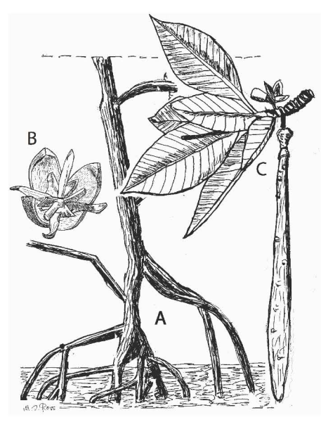

**Figure 6.1:** *Rhizophora apiculata*, the tall-stilted mangrove, prop-root mangrove: **A**, stilt roots and trunk; **B**, flower; **C**, leaves, fruit and hypocotyl (viviparous seedling).

On the landward margin the mangrove forest becomes more diverse, forming a canopy up to 25 m tall, which in the Bismarcks includes *Camptostemon schultzii* (no reconstruction), *Cerbera manghas* (§4.1), *Excoecaria agallocha* (§4.3), *Heritiera littoralis* (§4.4), *Inocarpus fagifer* (ch. 11, §2.2), *Intsia bijuga* (ch.7, §4.9), *Lumnitzera littorea* (no reconstruction) and *Xylocarpus granatum* (§4.6). *Intsia bijuga* and *Inocarpus fagifer* are also common lowland swamp forest and rain forest trees and the latter is also a nut tree. They are not treated here but in chapters 7 and 11 respectively. Because the landward margin of the mangrove forest is more open, it has an undergrowth of shrubs and low-stature trees including *Dolichandrone spathacea* (§4.2) and *Myristica hollrungii* (no reconstruction). The *Nypa fruticans* palm also grows on the landward side of estuarine swamps (§4.5) (Paijmans 1976:31-34, Mueller-Dombois & Fosberg 1998:50–5 1).

The following sections present reconstructions for plants which grow in the *Rhizophora* (§2) and *Bruguiera* (§3) zones of the mangrove forest and on the landward margin (§4).

## 2. The *Rhizophora* zone of the mangrove forest

### 2.1. *Rhizophora* spp., P *manguru*, B *natongtong* (Rhizophoraceae)

The outer zone of the mangrove forest in the Bismarcks and the Solomons is dominated by trees of the genus *Rhizophora*, in the Bismarcks usually by *Rhizophora apiculata*, known as the tall-stilted mangrove or prop-root mangrove, which usually grows to between 5 and 8 min height, but can grow as tall as 40 m. The trunk is usually not erect and branches irregularly.

*Rhizophora apiculata* is also found in the Solomons, Vanuatu and New Caledonia. There are two other, rather similar, Indo-Pacific *Rhizophora* species, *Rhizophora mucronata*, which does not grow east of the Bismarcks, and *Rhizophora stylosa*, the red mangrove, whose range stretches to western Polynesia.

The pale yellow flowers of *Rhizophora apiculata* grow in pairs just below the base of the leaf stalk. The mature fruit are irregular ovoids (shaped like an upsidedown pear) and grow to around 4–5 em. All *Rhizophora* species are viviparous, i.e. the seed, hidden in the mature fruit, germinates on the tree and produces a hypocotyl, a viviparous seedling, which eventually falls into the mud below. Hypocotyls are long narrow green cylindrical structures with irregular small brown lenticels (pores). They vary in length from 15 to 80 cm but are only about 2cm in diameter at their widest point (Peekel 1984: 400–401, Duke 2006).

The Bola of New Britain use *Rhizophora* species as building timber (Powell 1976). On Waya Island, Fiji, the roots were used to make baskets and fish-traps, and the bark was boiled to give a red dye which was also used as a preservative for ropes. The crushed tips of the roots provided medicine for thrush and coughs (Gardner & Pawley 2006).

The Proto Oceanic (POc) term for *Rhizophora* species was perhaps POc *wako(t), repeated here from ch.4, §2.4. Since it is *Rhizophora* species that have stilt roots, it is likely that the intended meaning of ‘mangrove’ in these glosses is *Rhizophora*, and the glosses of the Tawala, Mokilese and Ponapean reflexes suggest that POc *wako(t) may have been used metonymically for the whole tree and not just the roots.

| **PMP** |  | *waket | ‘mangrove root’ (ACD) |
| --- | --- | --- | --- |
| **POc** |  | *wako(t) | ‘mangrove root’ |
| PT | Tawala | *wakoya* | ‘mangrove’ |
| Mic | Kosraean | *ɒk-ɒk* | ‘mangrove root’ |
| Mic | Mokilese | *ak* | ‘mangrove’ |
| Mic | Ponapean | *ak* | ‘generic for mangroves’ |

PWOc *baul perhaps denoted *Rhizophora*: its Tolai reflex, *baul* ‘mangrove, *Rhizophora* apiculata’, contrasts with *toŋor*, the generic term for mangroves including both *Rhizophora* and *Bruguiera* species.

| **PWOc** |  | *baul | ‘mangrove, *Rhizophora* sp. (?)’ (Ross 1996d) |
| --- | --- | --- | --- |
| NNG | Kove | *vale* | ‘mangrove’ |
| NNG | Yabem | *(ka)bɔʔ* | ‘k.o. mangrove tree’ |
| PT | Duau | *pauli* | ‘mangrove’ |
| PT | Suau (Daui) | *pauli* | ‘mangrove’ |
| PT | Sariba | *pauli* | ‘mangrove (generic)’ |
| MM | Patpatar | *baul* | ‘mangrove’ |
| MM | Tolai | *baul* | ‘mangrove, *Rhizophora apiculata*’ |

As a generic, Saliba *pauli* includes *Ceriops tagal*, *Rhizophora* spp. and *Bruguiera* spp. (Margetts 2005h).

## 3. The *Bruguiera* zone of the mangrove forest

### 3.1. *Bruguiera* spp., P *ko’a* (Rhizophoraceae)

In the Bismarcks *Bruguiera gymnorrhiza*, the orange or large-leafed mangrove, dominates the inner zone of the mangrove forest. It often grows in stiff mud, as well as in tidal areas, and tolerates a wide range of salinity levels. It contrasts sharply in appearance with *Rhizophora apiculata*, as it is taller, 15-30 m tall, and has an erect trunk and regularly arranged lateral branches. Its rounded or plank-like buttresses branch over and over again as they near the ground. Sometimes there are also stilt roots. Traditionally, the fruit was rarely eaten. When it was, it was processed to remove the tannin, then cooked in coconut cream as a vegetable (Henderson & Hancock 1988: 105, 107, Allen & Duke 2006).

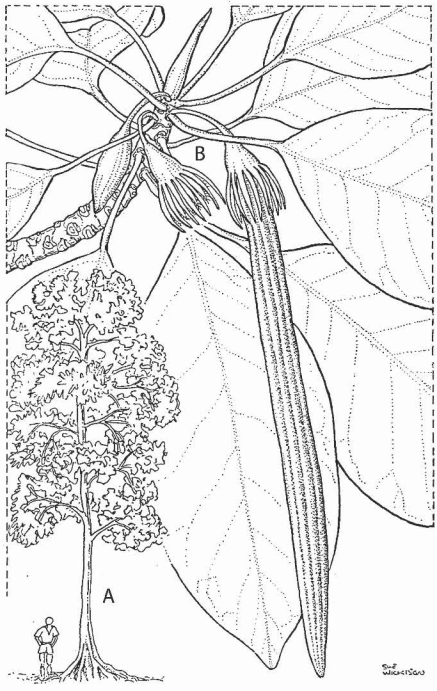

**Figure 6.2:** *Bruguiera gymnorrhiza*, orange mangrove: **A**, tree; **B**, shoot bearing edible fruit.

The wood of *Bruguiera gymnorrhiza* is hard, but it is not durable in water and is therefore used only for internal construction, e.g. rafters. It is also used to make charcoal (Streicher 1982, Peekel 1984: 400). The Nakanai also use it for axe handles and digging sticks (Floyd 1954). In areas where people depend on sago because they have little dryland agriculture, sprouted *Bruguiera* fruits are sometimes collected and subjected to lengthy processing so that they can be eaten (Barrau 1955: 25-26). The bark was used as an abortifacient in Malaita and for the treatment of bums in the western Solomons.

POc *toŋoR was fairly clearly the generic term for mangroves. It also seems to have been the term for *Bruguiera* species. This is the denotatum of its reflexes in non-Oceanic languages and in some of the Oceanic languages listed below (and I suspect that where the gloss is simply ‘mangrove’, this is sometimes simply the result of poor glossing).

| **PAn** |  | *teŋeR | ‘mangrove, *Bruguiera* spp.’ (Blust 1972b) |
| --- | --- | --- | --- |
| **POc** |  | *toŋoR | ‘mangrove, *Bruguiera* spp.; mangroves (generic)’ (Ross 1996d) |
| Adm | Mussau | *toŋo* | ‘mangrove sp. with edible fruit’ |
| NNG | Malai | *toŋor* | ‘mangrove’ |
| NNG | Tami | *toŋ* | ‘mangrove’ |
| NNG | Mindiri | *tuoŋ* | ‘mangrove’ |
| NNG | Bilibil | *toŋ* | ‘mangrove’ |
| NNG | Gedaged | *toŋ* | ‘mangrove’ |
| NNG | Yabem | *(ka)toʔ* | ‘mangrove’ |
| NNG | Numbami | *toloŋa* | ‘mangrove, *Bruguiera* spp.’ |
| PT | Sudest | *roŋʷe* | ‘mangrove, *Bruguiera* spp.’ |
| PT | Motu | *to-toa* | ‘*Rhizophora mucronata*’ (Lane-Poole 1925) |
| MM | Lavongai | *toŋoŋ* | ‘mangrove’ |
| MM | Tiang | *toŋoi* | ‘mangrove’ |
| MM | Minigir | *toŋor* | ‘mangrove, *Bruguiera* spp.’ |
| MM | Patpatar | *toŋ* | ‘mangrove’ |
| MM | Tolai | *toŋor* | ‘mangrove, *Bruguiera* and *Rhizophora* spp.’ |
| MM | Taiof | *toŋon* | ‘mangrove’ |
| MM | Mono-Alu | *tolo* | ‘*Rhizophora* spp.’ (W. McClatchey, pers. comm.) |
| **PEOc** |  | *toŋoR | ‘mangrove’ |
| SES | Gela | *toŋo* | ‘a mangrove’ |
| SES | Sa’a | *oŋo* | ‘mangrove’ |
| SES | ’Are’are | *ono* | ‘mangrove’ |
| NCV | Araki | *(vi)coŋo* | ‘*Rhizophora* sp.’ |
| NCV | Raga | *toŋ-toŋo* | ‘mangrove’ |
| NCV | Naman | *ne-doŋ* | ‘mangrove’ |
| NCV | Avava | *o-doŋ* | ‘mangrove’ |
| NCV | Uripiv | *na-roŋ* | ‘*Ceriops tagal*’ |
| NCV | Lonwolwol | *toŋ* | ‘mangrove’ |
| NCV | Paamese | *a-toŋo* | ‘mangrove’ |
| NCV | Namakir | *toŋotoŋ* | ‘mangrove’ |
| **PSV** |  | *na-doŋa(q) | ‘mangrove, *Rhizophora* spp.’ (Lynch 2001c) |
| SV | Sye | *(ne)tuŋo* | ‘mangrove, *Rhizophora* sp.’ |
| SV | Lenakel | *toŋo* | ‘mangrove’ |
| SV | Anejom̃ | *ne-ceŋ* | ‘mangrove, *Rhizophora* sp.’ |
| NCal | Nemi | *jen* | ‘mangrove’ |
| NCal | Nyelâyu | *jan* | ‘mangrove’ |
| NCal | Nêlêmwâ | *kan* | ‘*Bruguiera gymnorrhiza*’ |
| Mic | Kiribatese | *toŋo* | ‘mangrove (generic); *Bruguiera gymnorrhiza* and *Rhizophora mucronata*’ |
| Mic | Ponapean | *c̣oŋ* | ‘mangrove sp., bark of which is used for dyeing’ |
| **PCP** |  | *toŋo | ‘mangrove, probably *Bruguiera gymnorrhiza*; mangroves (generic)’ |
| Fij | Wayan | *toŋo* | ‘*Bruguiera gymnorrhiza*; also generic for mangrove spp. including *Bruguiera gymnorrhiza* and *Rhizophora* spp.’ |
| Pn | Tongan | *toŋo* | ‘mangrove’ |
| Pn | Niuean | *toŋo* | ‘legendary tree, said to be the mangrove’ |
| Pn | Rennellese | *toŋo* | ‘mangrove, *Bruguiera gymnorrhiza*’ |
| Pn | Tikopia | *toŋo* | ‘mangrove’ |
| Pn | Samoan | *toŋo* | ‘taxon of mangrove species inc. *Bruguiera gymnorrhiza* and *Rhizophora* mangle’ (Whistler 2000: 204) |
| Pn | Mangareva | *toŋo-toŋo* | ‘mangrove’ |

## 4. The landward margin of the mangrove forest

The landward margin of the mangrove forest looks more like a dryland rain forest than a mangrove swamp. Indeed, apart from *Excoecaria agallocha*, the plants below are described as growing ‘behind’ mangroves, i.e. behind the various stilt-rooted species. They are trees of the foreshore or the freshwater swamp rather than specialised plants of the mangrove swamp. The landward margin is more diverse, and accommodates an understorey which includes *Dolichandrone spathacea* (§4.2). Not all prominent plants of the landward margin have reconstructable POc labels. Terms for *Lumnitzera littorea*, *Camptostemon schultzii* and *Myristica hollrungii* cannot at present be reconstructed.

### 4.1. *Cerbera* spp. (Apocynaceae)

Three *Cerbera* species are associated with mangrove swamps. All three grow in coastal locations and are often associated with muddy habitats. Two, *Cerbera manghas* and *Cerbera floribunda*, are similar to each other, and some languages treat them as a single taxon. They are trees 10-20 m tall and about a metre in girth. The third, *Cerbera odollam*, is a large shrub or small tree about 10m in height. All three have shiny green leaves and sweet-scented white flowers with a red (*Cerbera manghas*) or yellow (*Cerbera odollam*) centre. The seed is surrounded by a thick fibrous husk which gives the fruit buoyancy and makes for easy dispersal on ocean currents.

The genus is named after Cerberus, the Greek mythological dog of Hades, because all its parts are highly toxic: they contain cerberin, a substance that blocks electric impulses in mammals, including the heart beat. Even smoke from burning *Cerbera* wood is toxic. In parts of the Pacific *Cerbera* sap was used to poison animals and people (Powell 1976, Tomlinson 1986). Whistler (1992) reports that the fruit was eaten by suicides in the Marquesas. On Waya Island an extract of the bark in oil was used to exorcise demons (Gardner & Pawley 2006).

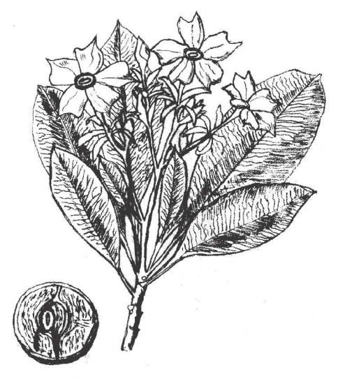

**Figure 6.3:** *Cerbera* odollam: bottom left, longitudinal section of fruit.

Two reconstructions are presented below: PWOc *(p,pʷ)awa(t) ‘*Cerbera* spp., probably *Cerbera floribunda* and *Cerbera manghas*’ and PCP *rewa ‘tree, *Cerbera* sp., probably *Cerbera* odollam’. Milke (1968) also offers POc *pasa ‘*Cerbera* sp.’, based on Gedaged *safa* (metathesis), Bauan *vasa* ‘*Cerbera odollam*’, Samoan *fasa*, ‘Uvea’[^1] *faha*, both ‘variety of pandanus’. The alleged metathesis and the semantic discrepancies make cognacy too uncertain for one to accept this reconstruction without further comparisons.

The initial rounded bilabial of POc *(p,pʷ)awa(t) is reconstructed on the basis of Teop *p-* (the usual Teop reflex of *p is *v-*. The final *-t is uncertain because it is reflected in Misima, but not where it is also expected, in Teop, Nduke, Roviana and Marovo.

| **POc** |  | *(p,pʷ)awa(t) | ‘*Cerbera* spp., probably *Cerbera floribunda* and *Cerbera manghas*’ |
| --- | --- | --- | --- |
| PT | Misima | *pawat* | ‘*Cerbera manghas*’ |
| MM | Lavongai | *bau* | ‘*Cerbera floribunda*’ |
| MM | Kara (East) | *vəu(kip)* | ‘*Cerbera manghas*’ |
| MM | Teop | *pau* | ‘*Cerbera manghas*’ (Record 1945) |
| MM | Nduke | *vao* | ‘*Cerbera* spp. inc. *Cerbera floribunda* and *Cerbera manghas*’ |
| MM | Roviana | *vao* | ‘*Cerbera* spp. inc. *Cerbera floribunda* and *Cerbera manghas*’ |
| MM | Marovo | *vao* | ‘*Cerbera* spp. inc. *Cerbera floribunda* and *Cerbera manghas*’ |
| SES | Gela | *vao-vao* | ‘large-leaved shrub sp.’ (possibly *Cerbera odollam*) |
| SES | Arosi | *hao-hao* | ‘tree sp.’ |
| SES | Lau | *fao-fao* | ‘tree sp., *Bombax malabaricum*’ |

| **PCP** |  | *rewa | ‘tree, *Cerbera* sp., probably *Cerbera* odollam’ |
| --- | --- | --- | --- |
| Fij | Wayan | *rewa* | ‘*Cerbera manghas*’ |
| Fij | Bauan | *rewa* | ‘*Cerbera odollam*, with long, narrow leaves’ |
| Pn | East Uvean | *leva* | ‘*Cerbera lactaria*’ |
| Pn | East Futunan | *leva* | ‘*Cerbera odollam*’ |
| Pn | Rennellese | *geβa* | ‘*Cerbera odollam*’ |
| Pn | Tikopia | *reva* | ‘tree that grows only on the mountain’ |
| Pn | Emae | *reva* | ‘*Cerbera odollam*’ |
| Pn | Ifira-Mele | *reva* | ‘*Cerbera odollam*’ |
| Pn | Samoan | *leva* | ‘*Cerbera odollam*’ |
| Pn | Rurutu | *(e)reva* | ‘*Cerbera manghas*’ |
| Pn | Tahitian | *reva* | ‘*Barringtonia* sp.’ |
| Pn | Rarotongan | *reva* | ‘*Cerbera lactaria*; false sea-mango, *Cerbera odollam*’ |
| Pn | Māori | *rewa-rewa* | ‘tree, *Knightia excelsa*, with long narrow leaves’ |

### 4.2. *Dolichandrone spathacea* (syn. *Bignonia spathacea*) (Bignoniaceae)

A tree of the understorey, 5-12 m tall, *Dolichandrone spathacea* grows behind mangroves and around the swampy mouths of streams from India to New Caledonia. Its fruit are up to 45cm long, flattened and curved like a bean pod with dark grey squarish seeds with thick corky wings. The large white flowers open after sunset and fall in the morning.

It is used in New Ireland to make propeller-like shark fishing floats (Peekel 1984: 508). In Marovo the wood is used for various canoe parts and sometimes for carving (Hviding 2005: 148) and in parts of Melanesia is used for hourglass drums (Record 1945). The Nakanai rub the bark on dermatitis and grille (*Tinea imbricata*, a disfiguring fungal skin infection) (Floyd 1954).

| **PMP** |  | *tuiʔ | ‘*Dolichandrone spathacea*’ (Blust 1986) |
| --- | --- | --- | --- |
| **POc** |  | *tui | ‘*Dolichandrone spathacea*’ |
| NNG | Gedaged | *tui* | ‘tree sp., Fabaceae, the stem of which is used to make canoes’ |
| NNG | Kairiru | *tui* | ‘*Dolichandrone spathacea*’ |
| MM | Nakanai | *tiu* | ‘*Dolichandrone spathacea*’ |
| MM | Madak | *(va)ti* | ‘*Dolichandrone spathacea*’ |
| MM | Babatana | *tui* | ‘*Dolichandrone spathacea*’ (W. McClatchey, pers. comm.) |
| MM | Ririo | *tui* | ‘*Dolichandrone spathacea*’ (W. McClatchey, pers. comm.) |
| MM | Roviana | *tui* | ‘tree with inedible bean-like fruit’ |
| MM | Marovo | *tui* | ‘*Dolichandrone spathacea*’ |
| SES | Gela | *tui* | ‘tree sp.’ |

### 4.3. *Excoecaria agallocha*, milky mangrove (Euphorbiaceae)

*Excoecaria agallocha* is a shrub or small tree with a thick trunk that mostly grows in saltwater inland of A vicennia, *Rhizophora* and *Bruguiera* species (Peekel 1984:316, Hviding 2005: 135). According to Hviding the sap is harmful to people’s eyes. He also notes that its dead, dry wood is very good for slow-burning firesticks and for fuel for cooking fires. On New Britain an infusion made from the leaves is mixed with the sap of a Liliaceae species and used against fever (Arentz et al. 1989: 91).

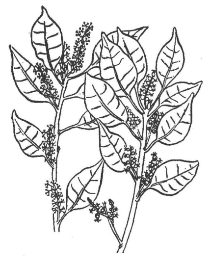

**Figure 6.4:** *Excoecaria agallocha*, milky mangrove.

Lynch (2004a) reconstructs PSOc *(t,d)oto(q), noting, ‘Final *-o is overtly reflected in at least Lenakel and the New Caledonian languages, suggesting final *-q.’ I reconstruct POc *dotoq ‘sticky liquids including the sap of (some?) trees’; ‘a mangrove tree, probably *Excoecaria agallocha*’ with initial *d- and final *-q because it appears to be an irregular reflex (for expected POc †*ditoq) of PAn *diteq ‘sticky substance’ (ACD). There are two sets of reasons for thinking that items meaning ‘sticky sap’ and items denoting *Excoecaria agallocha* (or in some cases *Cerbera manghas*, also a mangrove) reflect the same POc etymon.

- In the cognate set below, Marovo *ototo* ‘*Excoecaria agallocha*’ and Kwara’ae *toto(ŋʷala)* ‘*Cerbera manghas*’ are descriptive terms which allude to sticky sap. According to Hviding the Marovo name *ototo* means ‘with much sap’, an assertion supported by the fact that in closely related Nduke *oto-* means the ‘sap or gum of trees and some fruits’.[^2] Kwa’ioloa & Burt (2001: 162) gloss *toto(ŋʷala)* as ‘sticky sap; *Cerbera manghas*’.
- Reflexes in the cognate set below share in irregular developments which affect reflexes of POc *dotoq ‘sticky liquids …’. Kwara’ae *toto(ŋʷala)* reflects PSES *soso ‘sap’[^3] instead of expected PSES †*doto. Most other reflexes share in a voicing assimilation which reflects a variant *totoq. This idiosyncratic change affects both reflexes glossed ‘sticky sap’[^4] and reflexes glossed ‘*Excoecaria agallocha*’ (below), suggesting that they are indeed the same term.

| **POc** |  | *dotoq | ‘sticky liquids including the sap of (some?) trees’; ‘a mangrove tree, probably *Excoecaria agallocha*’ (Lynch 2004a: PSOc *(t,d)oto(q)) |
| --- | --- | --- | --- |
| MM | Bola | *toto* | ‘*Cerbera manghas*’ (Powell 1976) |
| MM | Marovo | *ototo* | ‘*Excoecaria agallocha*’ |
| SES | Kwara’ae | *toto(ŋʷala)* | ‘*Cerbera manghas*’ (irregular: see text above) |
| NCV | Mwotlap | *no-dot* | ‘*Excoecaria agallocha*’ |
| NCV | Mota | *noto* | ‘*Excoecaria agallocha*’ |
| NCV | Tamambo | *(vu)toto* | ‘tree sp. with sticky sap, grows near water’ |
| NCV | Uripiv | *na-tot* | ‘*Excoecaria agallocha*’ |
| **PSV** |  | *na-tetaq | ‘*Excoecaria agallocha*’ (Lynch 2001c) |
| SV | Sye | *yate* | ‘*Excoecaria agallocha*’ |
| SV | Lenakel | *təra* | ‘*Excoecaria agallocha*’ |
| SV | Anejom̃ | *ne-tet* | ‘*Excoecaria agallocha*’ |
| NCal | Nemi | *dao* | ‘*Excoecaria agallocha*’ |
| NCal | Nyelâyu | *jayo* | ‘*Excoecaria agallocha*’ |
| NCal | Iaai | *xic* | ‘*Excoecaria agallocha*’ |
| Pn | Tongan | *toto* | ‘*Cerbera* odollam’ |

### 4.4. *Heritiera littoralis* (Sterculiaceae)

*Heritiera littoralis* typically grows in sand at the high-tide limit of estuaries and mangrove swamps in the Bismarcks, the Solomons, Vanuatu and New Caledonia. Up to 25m tall, it has a short bole, straight trunk, planklike buttresses, and large conspicuous hard brown nuts about 7cm long and 4cm in diameter. Its wood is very strong when it has dried out, and is used among other things for rafters, planks and spear shafts (Peekel 1984: 374, Wheatley 1992:223-225, Kwa’ioloa & Burt 2001: 136, Hviding 2005: 101).

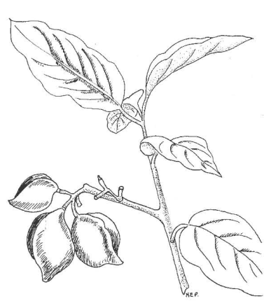

**Figure 6.5:** *Heritiera littoralis*

The cognate set below has few members, but they are widespread enough to support a POc reconstruction which entails the POc term *qone ‘sand, sandy beach’ or *qone-qone ‘sandy’ (vo1.2, ch.3, §7.5). If the interpretation of the Patpatar prefix *i-* offered in chapter 2, §7.1 is correct, then Patpatar *i-kon* points to POc *kayu qone, ‘tree of beach, beach tree’. Although Tolai *ka-* is not a regular prefix in tree names, it quite possibly reflects *kayu in this instance, as the latter must have been an intrinsic part of the name. Nyelayu *kʰon* reflects *kV-kon at a recent interstage and has a history like that of the Tolai reflex. PSES *(q)one-(q)one reflects POc *qone-qone ‘sandy’.

| **POc** |  | *kayu qone | ‘*Heritiera littoralis*’ |
| --- | --- | --- | --- |
| MM | Patpatar | *i-kon* | ‘*Heritiera littoralis*’ |
| MM | Tolai | *ka-kono* | ‘*Heritiera littoralis*’ (Record 1945) |
| NCal | Nyelâyu | *kʰon* | ‘*Heritiera littoralis*’ |

| **PSES** |  | *(q)one-(q)one | ‘*Heritiera littoralis*’ |
| --- | --- | --- | --- |
| SES | Kwara’ae | *one-one* | ‘*Heritiera littoralis*’ |
| SES | Lau | *one-one* | ‘*Heritiera littoralis*’ |
| SES | Arosi | *one-one* | ‘large tree sp. with brightly coloured foliage’ |

### 4.5. *Nypa fruticans*, nipa(h) palm (Arecaceae)

The nipa palm, *Nypa fruticans*, grows from the Bismarcks to Fiji in soft mud and slow moving tidal and river waters that bring in nutrients. It is the only palm (member of the Palmae family) that is also a mangrove, i.e. grows in soft mud. It has a horizontal trunk that grows beneath the ground; only the leaves and flower stalk grow vertically above the surface. From a distance, it looks like a clump of coconut fronds growing straight out of the water or the mud.

Its fronds are used for matting (Peekel 1984: 66) and for roofing, but it is not nearly as durable as sago thatch (Floyd 1954).

Final POc *-q of *nipaq is attested by the presence of paragogic *-i* in Saliba, which occurs only after a present or earlier word-final consonant.

| **PAn** |  | *nipaq | ‘*Nypa fruticans*’ (Wolff 1994: 532-533) |
| --- | --- | --- | --- |
| **POc** |  | *nipaq | ‘*Nypa fruticans*’ (Chowning 2001: 84) |
| PT | Sariba | *lihai* | (*l-* for *n- unexpected) |
| MM | Nduke | *niva* | ‘*Nypa fruticans*’ |
| MM | Kia | *nifa* | ‘*Nypa fruticans*’ (W. McClatchey, pers. comm.) |
| MM | Kokota | *nifa* | ‘palm sp.; has enormous multiple fruit’ |
| MM | Maringe | *nhiva* | ‘*Nypa fruticans*’ (W. McClatchey, pers. comm.) |
| SES | Gela | *niva* | ‘sago palim sp. smaller than sao’ |
| SES | Kwara’ae | *niva* | ‘*Nypa fruticans*’ (Whitmore 1966) |

### 4.6. *Xylocarpus* spp. (syn. *Xylocarpus obovatus*, *Carapa obovata*), puzzlenut tree (Meliaceae)

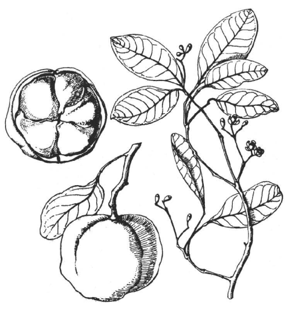

**Figure 6.6:** *Xylocarpus granatum*, puzzlenut tree: leaves flowers and fruit.

*Xylocarpus granatum* and *Xylocarpus moluccensis* are foreshore trees or shrubs, with a trunk 3-15 metres tall and up to 70cm in diameter. The wood is reddish and the old bark peels off to reveal new, papery bark inside. Both are widespread between mangrove stands and near the beach. *Xylocarpus granatum* has smaller fruit than *Xylocarpus moluccensis*, which has a large red fruit with flesh surrounding a seed which is triangular-pyramidal in shape and 5-8cm across. The fruit of *Xylocarpus moluccensis* hangs heavily and is larger than the fruits of other trees, earning the tree the name ‘testicles tree’ in Kwara’ae (*faʔi lalato*; Kwa’ioloa & Burt 2001: 122) and in Uripiv (*n-ai laslas*; J. Lynch, pers. comm.).[^5] The fruit is divided into four quadrants, each containing 3-5 irregular woody seeds (Johns 1976: 206). The: seeds are used by children as a puzzle, the goal of which is to put the fallen seeds together as a ball (Peekel 1984: 285). Hence the English label ‘puzzlenut’.

POc *tapi(l) is problematic because only the Muyuw reflex has a secure gloss, and because Gela *tavili* - if it is cognate - reflects a POc final consonant and a paragogic *-i*, suggesting that it is a loan from a nearby NW Solomonic language. The only secure reconstruction is PCP *legi-legi ‘puzzlenut tree, *Xylocarpus granatum*’.

| **POc** |  | *tapi(l) | ‘puzzlenut tree, *Xylocarpus granatum*’ (?) |
| --- | --- | --- | --- |
| PT | Muyuw | *tavi* | ‘*Xylocarpus granatum*’ (Damon 2004) |
| SES | Gela | *tavili* | ‘mangrove species’ |
| NCV | Lemerig | *n-ʔav-ʔav* | ‘*Rhizophora* sp.’ |

| **PCP** |  | *legi-legi | ‘puzzlenut tree, *Xylocarpus granatum*’ (Biggs 1965) |
| --- | --- | --- | --- |
| Fij | Rotuman | *leki-leki* | ‘*Xylocarpus granatum*’ |
| Fij | Wayan | *legi-legi* | ‘*Xylocarpus granatum*’ |
| Fij | Bauan | *legi-legi* | ‘*Xylocarpus granatum*’ |
| **PPn** |  | *leki-leki | ‘puzzlenut tree, *Xylocarpus* sp.’ |
| Pn | Tongan | *leki-leki* | ‘*Xylocarpus granatum* and *Xylocarpus moluccensis*’ |
| Pn | Samoan | *leʔi-leʔi* | ‘*Xylocarpus moluccensis*’ |

## Notes

[^1]: It is not clear whether Milke intends East Uvean or West Uvean.
[^2]: Marovo normally reflects POc *-q as *-k-*, followed by an echo vowel, but if this is the directly possessed (suffixed) noun ‘sap’, then loss of root-final *-q is regular.
[^3]: Cf Gela *sososo* ‘sap, juice’, Arosi *toto* ‘sap’.
[^4]: Cf Vitu (MM) *toto* ‘milk’, Mota (NCV) *totoa-* ‘juice of tree, thick fluid in bark’, Raga (NCV) *toto* ‘sap’ , Nguna (NCV) *totoa* ‘sap, exude sap’ (NCV items from Clark 1996), PPn *toto ‘blood, sap’ (POLLEX).
[^5]: These items may reflect a PEOc etymon with a form something like *kayu ni laso-laso, but it is also possible that the Kwara’ae and Uripiv terms are independent coinages.